# Ferromagnetismo

## Introdução

- Modelo de Heisenberg:
  - Considera apenas a interacção entre electrões desemparelhados.
  - Para simplificação vamos considerar apenas um electrão por nó da rede cristalina.
  - Podemos considerar uma interacção de curto alcance devida apenas aos spins dos electrões.

A energia de interacção entre dois electrões pode ser escrita como:

$E_\pm = I_0 \pm \frac{J}{2}$

com + para spins anti-paralelos e - para spins paralelos. $I_0$ deve-se à interacção de Coulomb e $J/2$ é o chamado integral de troca e que se deve à interacção spin-spin.

A diferença de energias entre um estado de spins paralelos e um anti-paralelos é:

$\Delta E = E_+ - E_- = J$

Se J > 0 então os estados paralelos têm menor energia, e tem-se ferromagnetismo, se J < 0 os estados anti-paralelos têm menor energia e tem-se anti-ferromagnetismo.

## Modelo de Ising

Considerando o caso em que S = 1/2 a energia total vai ser dada por:

$E = -\frac{1}{2} \sum_{i, j}{J_{i, j}\sigma_i\sigma_j} - \mu B \sum_{i}{\sigma_i}$

com $\sigma_i = \pm 1$ e $\sigma_j = \pm 1$

Ou seja mesmo na ausência de campo externo o estado mínimo de energia correposnde a todos os spins alinhados e à produção de campo magnetico pelo próprio material.

Para efectuar a simulação segundo o modelo de Ising vamos produzir o seguinte programa:

1. Incialização da rede.
2. Em cada ponto da rede
   1. Calcula-se a variação de energia no caso de inversão de spin
   2. Se a variação de energia for negativa o spin é invertido.
   3. Se a variação de energia for positiva atribui-se uma probablidade à inversão de spin (*função de transição, w*).
   4. Produz-se um número aleatório, r. Se r < w há inversão de spin.
   5. Termina o ciclo de Monte Carlo.
3. Calcula-se as grandezas físicas associadas à nova configuração da rede.

## Função de transição

A variação de energia devido à inversão de um spin na componente spin-spin é dada por:

$\Delta \epsilon = J\left(\sigma_{i inicial} \sum_j{\sigma_j} - \sigma_{i final}\sum_j{\sigma_j}\right) = J\left(\pm 2\sum_j{\sigma_j}\right) = 2 J \delta$

com $\delta = \pm \sum_j{\sigma_j} = -4; -2; 0; 2; 4$

Nas situações em que $\Delta \epsilon < 0 \Longrightarrow w = 1$

Nas situações em que $\Delta\epsilon > 0 \Longrightarrow w = e^{-\frac{2\delta}{t}}$ em que t é a temperatura reduzida.

Quando se tem campo magnetico externo a função de transição fica:

$w = \begin{cases} 1, \Delta\epsilon < 0\\ e^{-\frac{\delta + \sigma_{i inicial}h}{t}}, \Delta\epsilon > 0 \end{cases}$

com h campo magnético reduzido

Em vez de calcularmos a função de transição em cada ponto da rede produzimos a tabela de todos os valores possíveis da função de transição antes de iniciar os ciclos de Monte Carlo. Fazendo-se o mesmo procedimento para as indexações das posições vizinhas.

## Variáveis reduzidas

Vamos usar as variáveis reduzidas:

$t = \frac{K T}{J}$

$h = \frac{\mu_B B}{J}$

Queremos observar o comportamento da rede a diferentes temperaturas e campos externos aplicados para as grandezas:

- Momento magnético, m. Devido a trocas de sentido perto da temperatura crítica vamos considerar o modulo do momento magnético.
- Energia média por ponto de rede.
- Susceptibilidade magnética.
- Capacidade calorífica.

## Simulação

### Grandezas a analisar

- o momento magnético médio da rede e com o factor de ordem $$ m = \frac{||\overline{M}||}{L^2}$$
- energia média por ponto de rede $$ \overline{\epsilon} = \frac{\overline{E}}{L^2}$$
- susceptibilidade magnética $$ \chi = \frac{\sigma^2\left(M\right)}{t}L^2$$
- capacidade calorífica $$ C = \frac{\sigma^2\left(\epsilon\right)}{t^2L^2}$$

```python
t = 5.5
h = 0.
tamanho = 10
rede, order, e = ferroSimul(tamanho, 10000, t, h)
```

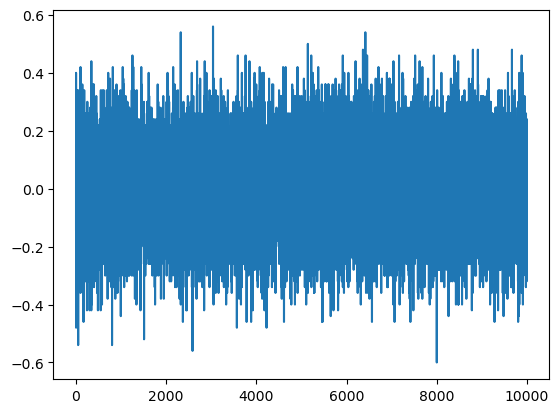

```python
plt.plot(order)
```

```python
order[1000:].mean()
```

```
0.0028911111111111117
```

```python
np.abs(order[1000:]).mean()
```

```
0.12742
```

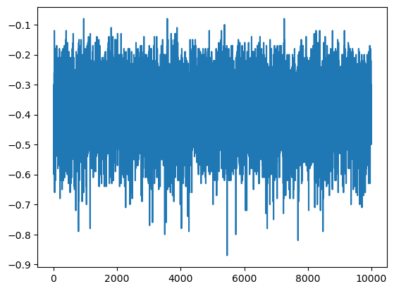

```python
plt.plot(e)
```

```python
e[1000:].mean()
```

```
-0.38432666666666665
```

```python
sus = order.var() * tamanho ** 2 / t
sus
```

```
0.4594423726545455
```

```python
C = e.var() / (tamanho ** 2 * t ** 2)
C
```

```
3.4572013193388428e-06
```

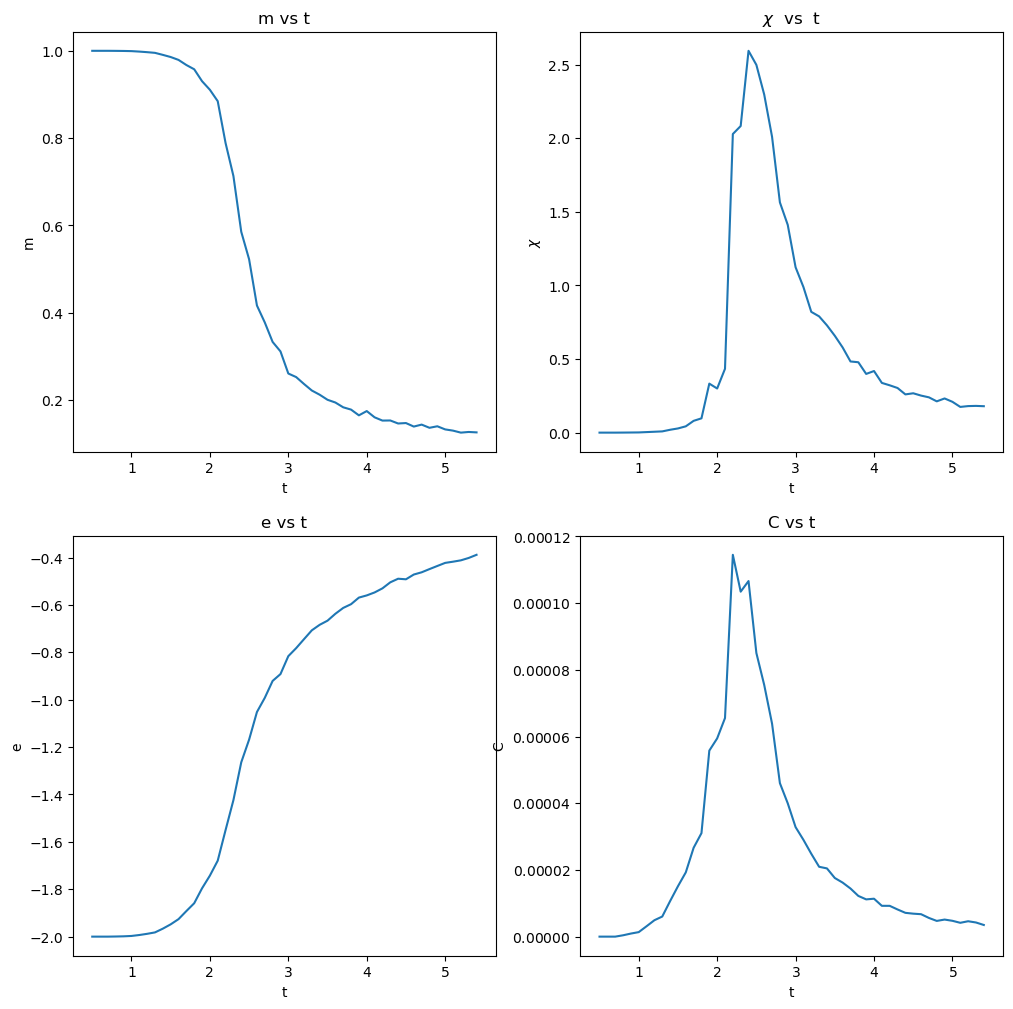

```python
temps = np.arange(0.5, 5.5, .1)
m, sus, e, c = simulacao_temp(temps, 10, 1000, 0)
fig1 = ferro_graf(m, sus, e, c, temps)
fig1
```

```python
max_sus = sus.max()
temps[sus == max_sus]
```

```
array([2.4])
```

```python
max_c = c.max()
temps[c == max_c]
```

```
array([2.2])
```

```python
output = np.array([temps, m, sus, e, c]).transpose()
```

```python
np.savetxt('0.tsv', output, delimiter='\t')
```

```python
data = np.loadtxt('0.tsv', delimiter='\t')
data
```

```
array([[ 5.00000000e-01,  1.00000000e+00,  0.00000000e+00,
        -2.00000000e+00,  0.00000000e+00],
       [ 6.00000000e-01,  1.00000000e+00,  0.00000000e+00,
        -2.00000000e+00,  0.00000000e+00],
       [ 7.00000000e-01,  1.00000000e+00,  0.00000000e+00,
        -2.00000000e+00,  0.00000000e+00],
       [ 8.00000000e-01,  9.99866667e-01,  3.31111111e-04,
        -1.99946667e+00,  4.01805556e-07],
       [ 9.00000000e-01,  9.99666667e-01,  8.27160494e-04,
        -1.99868889e+00,  9.19792715e-07],
       [ 1.00000000e+00,  9.99288889e-01,  1.37165432e-03,
        -1.99715556e+00,  1.35242469e-06],
       [ 1.10000000e+00,  9.98222222e-01,  3.67227834e-03,
        -1.99317778e+00,  3.11580859e-06],
       [ 1.20000000e+00,  9.96888889e-01,  6.00823045e-03,
        -1.98813333e+00,  4.92024691e-06],
       [ 1.30000000e+00,  9.95333333e-01,  8.37606838e-03,
        -1.98215556e+00,  6.02510337e-06],
       [ 1.40000000e+00,  9.90711111e-01,  1.94241975e-02,
        -1.96635556e+00,  1.06487881e-05],
       [ 1.50000000e+00,  9.85777778e-01,  2.84115226e-02,
        -1.94813333e+00,  1.51045136e-05],
       [ 1.60000000e+00,  9.79177778e-01,  4.28188580e-02,
        -1.92622222e+00,  1.92663002e-05],
       [ 1.70000000e+00,  9.67488889e-01,  8.00735221e-02,
        -1.89213333e+00,  2.66463053e-05],
       [ 1.80000000e+00,  9.57711111e-01,  9.71163512e-02,
        -1.85910000e+00,  3.10355658e-05],
       [ 1.90000000e+00,  9.30422222e-01,  3.32879506e-01,
        -1.79610000e+00,  5.57753493e-05],
       [ 2.00000000e+00,  9.10777778e-01,  2.99680864e-01,
        -1.74252222e+00,  5.94365960e-05],
       [ 2.10000000e+00,  8.84622222e-01,  4.33606961e-01,
        -1.67935556e+00,  6.55359693e-05],
       [ 2.20000000e+00,  7.88755556e-01,  2.02831345e+00,
        -1.55030000e+00,  1.14484433e-04],
       [ 2.30000000e+00,  7.13288889e-01,  2.08267946e+00,
        -1.42398889e+00,  1.03433270e-04],
       [ 2.40000000e+00,  5.85488889e-01,  2.59350393e+00,
        -1.26425556e+00,  1.06618444e-04],
```

[output cut: 45 more lines]

```
        -4.62411111e-01,  5.60498360e-06],
       [ 4.80000000e+00,  1.36600000e-01,  2.12490648e-01,
        -4.48844444e-01,  4.71257630e-06],
       [ 4.90000000e+00,  1.40088889e-01,  2.32126823e-01,
        -4.35700000e-01,  5.11696932e-06],
       [ 5.00000000e+00,  1.32911111e-01,  2.09297175e-01,
        -4.22688889e-01,  4.74439684e-06],
       [ 5.10000000e+00,  1.30111111e-01,  1.74631566e-01,
        -4.17622222e-01,  4.14554725e-06],
       [ 5.20000000e+00,  1.25533333e-01,  1.80257350e-01,
        -4.11944444e-01,  4.61435619e-06],
       [ 5.30000000e+00,  1.27044444e-01,  1.81596189e-01,
        -4.01877778e-01,  4.24125887e-06],
       [ 5.40000000e+00,  1.26111111e-01,  1.79481253e-01,
        -3.88600000e-01,  3.49262155e-06]])
```

```python
fig1.savefig('ferro.svg', dpi=1200)
```

## Desenho da simulação

- Se variar a temperatura ou o campo devo começar com a rede inicializada sempre da mesma forma ou no novo valor de t ou h começar com a rede como terminou o valor anterior? Vantagens e desvantagens
- Que números de ciclos iniciais se devem não contabilizar para efeitos de obtenção de valores? 10%, valor fixo, outros?
- Tamanho da rede, fronteiras abertas ou fechadas?
- Que valores simular, com que passos?
- Temos dados experimentais para verificar parte ou toda a simulação?
- Qual o objectivo da simulação?

## Exercício - Ano 21/22

Usando e ou alterando o código feito até ao momento simular a rede com t = {0.5, 2.4, 2.5, 2.6, 4.5} e h = {-4, -2, -1, 0, 1, 2, 4}. Apresentar um gráfico de m em função de h para cada t.

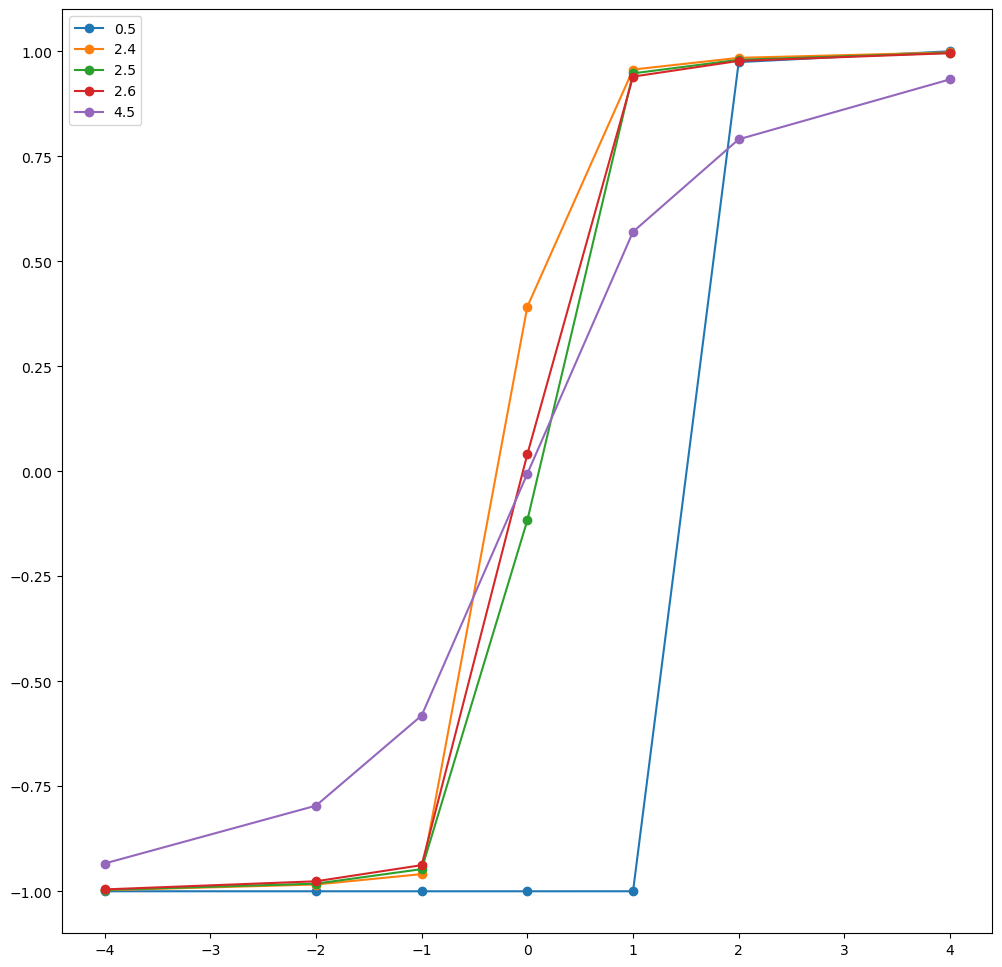

```python
fig, ax = plt.subplots(figsize = (12, 12))
for i in range(tamanho_t):
    ax.plot(campo, mh.transpose()[i], '-o', label = temp[i])
ax.legend()
```

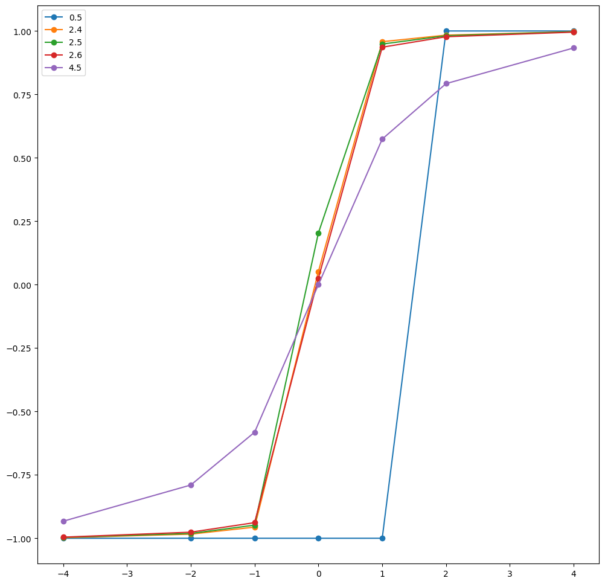

```python
fig2, ax2 = plt.subplots(figsize = (12, 12))
for i in range(tamanho_t):
    ax2.plot(campo, mt[i], '-o', label = temp[i])
ax2.legend()
```

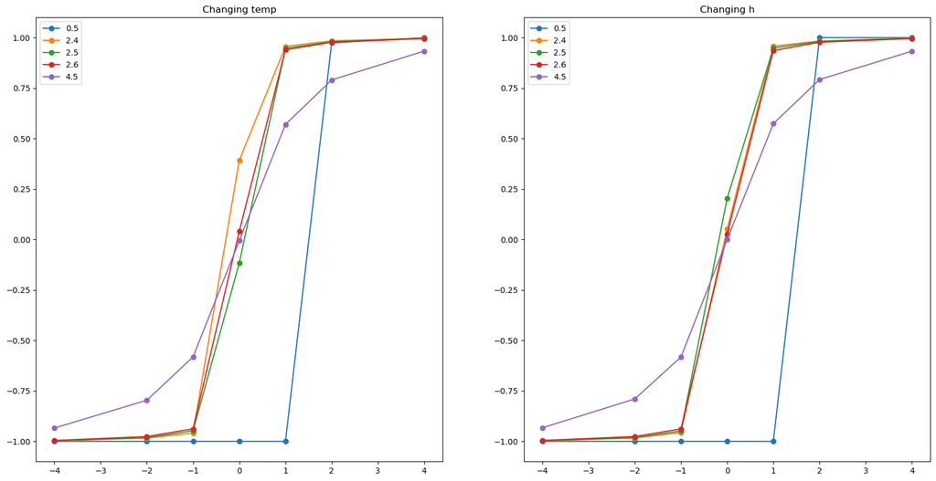

```python
fig3 = plt.Figure()
axt = fig3.add_subplot(1, 2, 1)
for i in range(tamanho_t):
    axt.plot(campo, mh.transpose()[i], '-o', label = temp[i])
axt.legend()
axt.set_title('Changing temp')

axh = fig3.add_subplot(1, 2, 2)
for i in range(tamanho_t):
    axh.plot(campo, mt[i], '-o', label = temp[i])
axh.legend()
axh.set_title('Changing h')

fig3.set_size_inches(20, 10)
fig3
```

## Exercício - Ano 22/23

- Para h = 0 obter a melhor estimativa da $t_c$
- Usando e ou alterando o código feito até ao momento simular a rede com t = {0.5, 2., 3., 4.5} e h a variar de -4 a 4 e voltando a -4 com passos de 0.5. Apresentar um gráfico de m em função de h para cada t.